# A Demonstration of the Central Limit Theorem Using the Exponential Distribution

March 7, 2015

## Overview

The purpose of this project is to investigate the exponential distribution in **R** and compare it with the Central Limit Theorem. The Central Limit Theorem states that the means of random samples drawn from any distribution with mean $m$ and variance $s^2$ will have an approximately normal distribution with a mean equal to $m$ and a variance equal to $s^2 / n$. This project involves running a simulation to generate a distribution of exponentials, comparing the sample mean and variance to the theoretical mean and variance, and showing that the distribution is approximately normal.

## Simulations

The exponential distribution can be simulated in **R** using the `rexp(n, lambda)` function, where $n$ is the number of observations and $lambda$ is the rate parameter. First, set the random number seed so the results are reproducible. Next, generate a distribution of 1000 means of $n = 40$ exponentials with a rate parameter of $lambda = 0.2$.

```r
set.seed(42)
mns = NULL
n <- 40
lambda <- 0.2
for (i in 1:1000){
   mns  = c(mns, mean(rexp(n, lambda)))
}
```

## Sample Mean versus Theoretical Mean

How does the sample mean compare to the theoretical mean?

```r
mean(mns) # sample mean
```

```
## [1] 4.986508
```

```r
print(1 / lambda) # theoretical mean
```

```
## [1] 5
```

The sample mean is very close to the theoretical mean, as would be expected under the Central Limit Theorem.

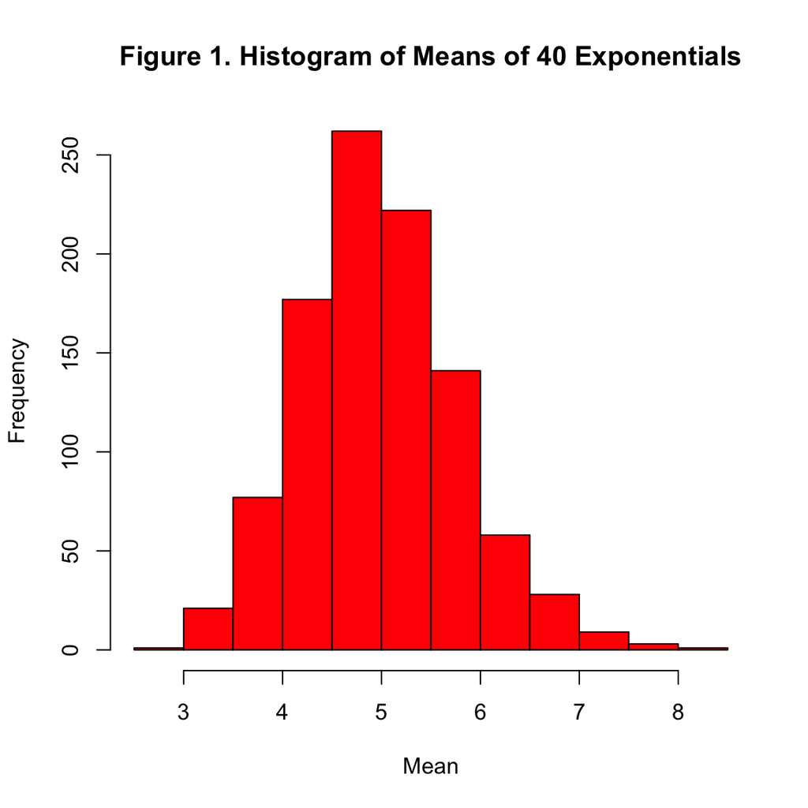

```r
# plot a histogram of the 40 means
hist(mns, main = "Figure 1. Histogram of Means of 40 Exponentials",
     xlab = "Mean", col = "red")
```

As shown in Figure 1, the means appears to be normally distributed, with the distribution centered around the theoretical mean of 5.

## Sample Variance versus Theoretical Variance

How does the sample variance compare to the theoretical variance?

```r
var(mns) # sample variance
```

```
## [1] 0.6344405
```

```r
print(1 / (lambda^2 * n)) # theoretical variance
```

```
## [1] 0.625
```

The sample variance is very close to the theoretical variance, again as would be expected under the Central Limit Theorem.

## Distribution

Finally, is the distribution of means approximately normal? Figure 2 shows a Q-Q plot of sample quantiles from the distribution of means against theoretical quantiles from a normal distribution. Q-Q plots are used to see how well a theoretical distribution models empirical data. The linear trend indicates that the distribution of means is approximately normal, as would be expected under the Central Limit Theorem.

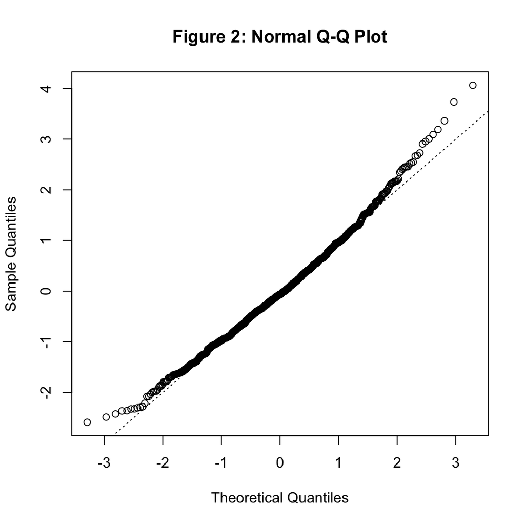

```r
mns_scale <- scale(mns) # convert the means to standard Z scores
qqnorm(mns_scale, main = "Figure 2: Normal Q-Q Plot")
abline(0, 1, lty = 3)
```

The results of this project demonstrate that means of random samples drawn from the exponential distribution with mean $m$ and variance $s^2$ have an approximately normal distribution with a mean equal to $m$ and a variance equal to $s^2 / n$.